# AM10: Computing for Science and Engineering - Module 2

## Homework 05

**Fall 2020**

Handed out: Thursday, Oct. 8, 2020

Due: 11.59 am; Thursday, Oct. 15, 2020

```python
import numpy as np
import matplotlib.pyplot as plt
```

### Problem 1: Falling object with position-dependent drag

In this problem you will compute position, velocity, and accelaration of an object falling under gravity with frictional drag (similar to the exercises done in lecture and section).

The force on the mass is given by $$F(t) = -mg + \frac{1}{2} \gamma(x) [v(t)]^2,$$ as you have seen before. This time the drag coefficient, $\gamma$ is position-dependent with the following form.

$\gamma(x) = \gamma_0e^{-kx(t)}$.

Let's think of what this means. While $x>>1$ the drag is nearly zero. As $x$ approaches $0$ the drag approaches the value $\gamma_0$. As $x$ becomes negative, the drag increases exponentially. Also, note that larger the value of $k$, steeper is the exponential increase. So, this position dependent drag coefficinet is like a simple toy model of an object falling through a material interface at $x=0$, i.e., falling from one medium with low drag (say air) into another with very high drag (say oil).

Feel free to copy code from the lecture and/or section and modify appropriately. Use $\gamma0=1$ and $k=0.5$.

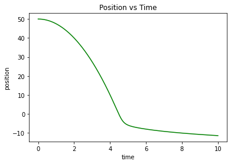

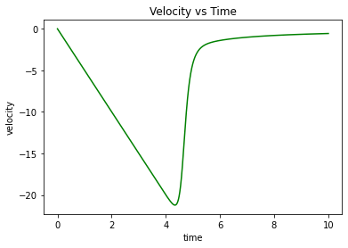

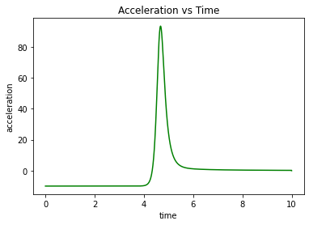

```python
# Define constants
mass = 5.0
g = 10.0
gam0 = 1.0
k= 0.5

# Define variables
tmax = 10
nt = 10000
t = np.linspace(0, tmax, nt)
dt = t[1]-t[0]
dt2 = dt**2

# Initialize variables
gamma=np.zeros(nt)
x = np.zeros(nt)
v = np.zeros(nt)
a = np.zeros(nt)

# Define initial conditions
x[0] = 50
v[0] = 0.0
gamma[0]=gam0*np.exp(-k*x[0])
# Loop for the time propagation of position, velocity, acceleration
for n in range(nt-1):
    gamma[n]= gam0*np.exp(-k*x[n])
    # acceleration
    a[n] = -g + 0.5 * (gamma[n]/mass) * (v[n])**2
    # position
    x[n+1] = x[n] + v[n] * dt + 0.5 * a[n] * dt2
    # velocity
    v[n+1] = (x[n+1] - x[n]) / dt

# Plot results
plt.plot(t, x, 'g')
plt.ylabel('position')
plt.xlabel('time')
plt.title('Position vs Time')
plt.show()
plt.plot(t, v, 'g')
plt.ylabel('velocity')
plt.xlabel('time')
plt.title('Velocity vs Time')
plt.show()
plt.plot(t, a, 'g')
plt.ylabel('acceleration')
plt.xlabel('time')
plt.title("Acceleration vs Time")
plt.show()
```

*Bonus* **Part B:** At what point in time does the falling object hit the interface (i.e., crosses $x=0$)? What is the velocity and acceleration at that point in time? Answer the above questions using at least two different coding approaches.

*Hint:* One possible approach is to use a `while` loop and run as long as $x$ is positive, then print out the values of time, velocity, and acceleration after the loop exits. Another approach is to use a `for` loop long enough to capture the transition through $x=0$, then find the index where $x$ approaches zero, and use that index to find the values of time, velocity, and acceleration.

```python
# WHILE loop

# Define initial conditions
x0 = 50
v = 0.0
t = 0

# Define empty lists to hold variables
pos = [x0]
vel = [0]
acc = [-g]
time = [0]

# Loop for the time propagation of position, velocity, acceleration
while x0 > 0:
    # update drag
    gamma = (gam0*np.exp(-k*x0))
    # acceleration
    a = -g + (0.5 * gamma/mass) * (v**2)
    # position
    x1 = x0 + v * dt + 0.5 * a * dt2
    # velocity
    v = (x1 - x0) / dt
    # update position
    x0 = x1
    # update time
    t = t + dt
    # append lists
    acc.append(a)
    vel.append(v)
    pos.append(x1)
    time.append(t)
# Print out results
print('At contact with the interface using WHILE loop:')
print('position =', '{:f}'.format(x0))
print('velocity =', '{:f}'.format(v))
print('acceleration =', '{:f}'.format(a))
print('time =', '{:f}'.format(t))
# FOR loop
tmax = 10
nt = 1000
t = np.linspace(0, tmax, nt)
dt = t[1]-t[0]
dt2 = dt**2

# Initialize variables
gamma=np.zeros(nt)
x = np.zeros(nt)
v = np.zeros(nt)
a = np.zeros(nt)

# Define initial conditions
x[0] = 50
v[0] = 0.0
gamma[0]=gam0*np.exp(-k*x[0])
# Loop for the time propagation of position, velocity, acceleration
for n in range(nt-1):
    gamma[n]= gam0*np.exp(-k*x[n])
    # acceleration
    a[n] = -g + 0.5 * (gamma[n]/mass) * (v[n])**2
    # position
    x[n+1] = x[n] + v[n] * dt + 0.5 * a[n] * dt2
    # velocity
    v[n+1] = (x[n+1] - x[n]) / dt
    if x[n] < 0:
        break
print('')
# Print out results
print('At contact with the interface using FOR loop:')
print('position =', '{:f}'.format(x[n]))
print('velocity =', '{:f}'.format(v[n]))
print('acceleration =', '{:f}'.format(a[n-1]))
print('time =', '{:f}'.format(t[n]))
```

[output not shown]

### Problem 2: Exploring early exponential growth rate from COVID-19 data

In this problem, you will compare the early growth rate of COVID-19 cases in the US using a simple phenomenological model and the real data.

We will use the following phenomenological model

\begin{equation} C(t) = \left [ r(1-p)t + C_0^{1-p} \right ]^{\frac{1}{1-p}}, \end{equation}

where $C(t)$ is the cumulative number of cases as a function of time, $C_0$ is the number of cases at $t=0$, $r$ denotes the growth rate, $p$ is the "deceleration of growth" parameter.

This model has been used to describe early epidemical growth of HIV and Ebola (see [this reference](https://pubmed.ncbi.nlm.nih.gov/27451336/) for details). We would like to test whether this model captures the early rate of growth of COVID-19 cases in the US.

**Part A:** Calculate rate of growth of daily cases from the data in the file `AM10-HW05-US-cases-timeseries.txt`. This file contains two columns, the first column represents days, while the second column represents the cumulative number of cases. The rate of growth of daily cases can be found by taking the first derivative of this data. Feel free to use the `central_diff` function you created in the lab. The data in this file was obtained from the [Johns Hopkins Covid-19 data repository](https://github.com/CSSEGISandData/COVID-19).

**Part B:** Calculate the rate of growth of daily cases using a fit from the model, i.e., calculate $dC/dt$ using the equation above. Use the following parameters, which have been determined through a fit to the data. $r=0.174$, $p=0.9999$, and $C_0=1$.

**Part C:** Plot the rate of growth of daily cases from part A and part B on the same figure.

```
Part C
```

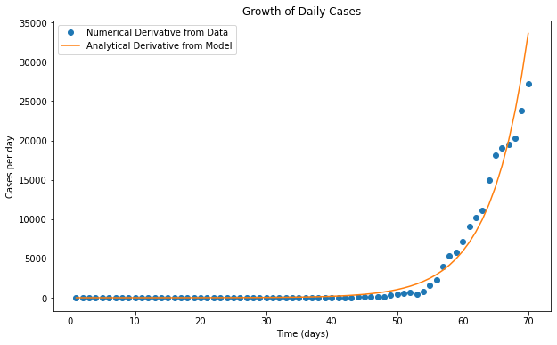

```python
# Part A
data=np.loadtxt("AM10-HW-05-US-cases-timeseries.txt")
time=data[:,0]
cases=data[:,1]
dx=1
def central_diff(cases, dx):
    nx = len(cases)
    d1_cent=np.zeros(nx)
    for n in range (1, nx-1):
        d1_cent[n] = (cases[n+1] - cases[n-1]) / (2.0 * dx)

    # Improve end points by first-order extrapolation
    d1_cent[0] = 2 * d1_cent[1] - d1_cent[2]
    d1_cent[nx - 1] = 2 * d1_cent[nx - 2] - d1_cent[nx - 3]

    return d1_cent
numerical_deriv=central_diff(cases,dx)

# Part B
t=np.arange(1,70.1,1)
cprime=(10000)*((0.174*t-0.1739826*t+1))**(9999)*(0.174-0.1739826)

print('Part C')
fig1, ax1 = plt.subplots(figsize=(10, 6))
ax1.set_xlabel('Time (days)')
ax1.set_ylabel('Cases per day')
ax1.plot(time, numerical_deriv , 'o',label='Numerical Derivative from Data')
ax1.plot(t, cprime, '-', label='Analytical Derivative from Model')
ax1.legend()
ax1.set_title("Growth of Daily Cases")
plt.show(fig1)
```

*Bonus* **Part D:** It appears that the model nicely describes the data and that the early growth looks nearly exponential. One way to visually check whether something is exponential is to plot it on a semilog scale and see if the data is linear. Try plotting the same results on a log scale for the $y$ axis. What would do you conclude now?

*Hint:* instead of the `plot` function, use the `semilogy` function.

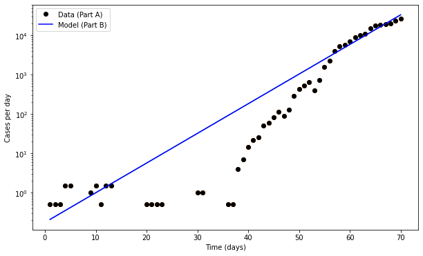

[output not shown]

```python
fig1, ax1 = plt.subplots(figsize=(10, 6))
log_model=plt.semilogy(t,cprime)
log_numerical=plt.semilogy(time,numerical_deriv,'o')
ax1.set_xlabel('Time (days)')
ax1.set_ylabel('Cases per day')
ax1.plot(time, numerical_deriv , 'ko',label='Data (Part A)')
ax1.plot(t, cprime, 'b-', label='Model (Part B)')
ax1.legend()
plt.show(fig1)
print("I conclude that the growth in the MODEL is exponential because when plotted on a semilog scale, the graph is  linear. However, the data itself is not entirely exponential, since the data only appears linear from around day 55 to around day 70. Before day 55, the data does not appear linear on the semilog scale therefore I am hesistant to say that the data trend is exponential")
```

### Problem 3: Second derivative using the three point formula

You have already written a function that evaluates the first derivative using the central difference formula. In this problem, you have to write a function that evaluates the second derivative using the three point formula, as shown below. \begin{equation} f''(n) = \frac{f(n+1)-2f(n)+f(n-1)}{dx^2} \end{equation}

**Part A:** Write a function named `three_point_diff` that implements the above equation. The inputs to this function should be the discretized function `fx` that needs to be differentiated and the resolution `dx`. The output of this function should be the differentiated function `d2fx`.

**Part B:** Now test `three_point_diff` by differentiating the function below in the range $0\leq x\leq 10$. Use $\mu=5$ and $dx=0.5$. Calculate the second derivative again, this time using `central_diff` twice.

\begin{equation} f(x) = \frac{1}{e^{\mu-x} + 1} \end{equation}

**Part C:** Plot the results from part B (the derivatives using `three_point_diff` once and `central_diff` twice) on the same figure.

```
Part C
```

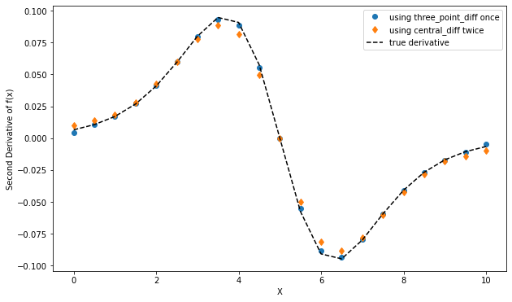

```python
# Part A
def three_point_diff(fx, dx):
    nx = len(fx)
    d2fx=np.zeros(nx)
    for n in range (1, nx-1):
        d2fx[n] = (fx[n+1]-(2*fx[n]) + fx[n-1]) / ((dx)**2)

    # Improve end points by first-order extrapolation
    d2fx[0] = 2 * d2fx[1] - d2fx[2]
    d2fx[nx - 1] = 2 * d2fx[nx - 2] - d2fx[nx - 3]

    return d2fx
# Part B
dx=0.5
x=np.arange(0,10.1,dx)
fofx=1/(np.exp(5-x)+1)

d2fx_deriv=three_point_diff(fofx,dx)
first_deriv=central_diff(fofx,dx)
second_deriv=central_diff(first_deriv,dx)

def true_deriv(x,u):
    z = -1*(np.exp(x) - np.exp(u))*np.exp(x+u)/((np.exp(x) + np.exp(u))**3)
    return z

print("Part C")
fig1, ax1 = plt.subplots(figsize=(10, 6))
ax1.set_xlabel('X')
ax1.set_ylabel('Second Derivative of f(x)')
ax1.plot(x,d2fx_deriv , 'o',label='using three_point_diff once')
ax1.plot(x,second_deriv, 'd', label='using central_diff twice')
ax1.plot(x,true_deriv(x,5),'k--',label="true derivative")
ax1.legend()
plt.show(fig1)
```

*Bonus* **Part D:** You can notice that the result from applying the three-point and central diffence formulae give slighly different results. Which method is more accurate? Why?

*Hint:* You can calculate the difference between the numerical derivatives and the analytical derivative to obtain a quantification of the error. Or you could go back to the Taylor expansion and try to think how these difference formulae might relate to the terms and see if you can conclude why one formula might be more accurate than the other.

```python
three_point_error=np.sum(np.absolute(true_deriv(x,5)-three_point_diff(fofx,dx)))
central_diff_twice_error=np.sum(np.absolute(true_deriv(x,5)-central_diff(first_deriv,dx)))
print("The sum of the absolute error from using the three point method once =", three_point_error)
print("The sum of the absolute error from using the central difference method twice=", central_diff_twice_error)
print("The three point difference is more accurate as you can see. This make sense logically because when you perform an operation twice instead of once you are introducing error twice instead of just once.")
```

```
The sum of the absolute error from using the three point method once = 0.02055398757573607
The sum of the absolute error from using the central difference method twice= 0.07377434487689913
The three point difference is more accurate as you can see. This make sense logically because when you perform an operation twice instead of once you are introducing error twice instead of just once.
```